# Working Example: Mapping Indeterminate Specimens

This article reproduces, in full, the working example originally published as Supporting Information (Appendix S1) in the `refloraR` software note:

> Calderón del Cid, C., Versiane, A.F.A., Leitman, P., Filardi, F.R., Forzza, R.C. & Cardoso, D. 2026. *refloraR*: An R package for efficiently retrieving and analyzing plant specimen data from the Herbário Virtual Reflora. **Applications in Plant Sciences**, e70081. https://doi.org/10.1002/aps3.70081

The example combines `reflora_records()` and `reflora_indets()` to quantify and map **indeterminate specimens** — records identified only to family or genus level — as an operational indicator of unresolved identifications and potential taxonomic knowledge gaps within and among Reflora-hosted herbaria. As the paper notes, some poorly known or undescribed species may be misidentified rather than left indeterminate, so `reflora_indets()` should be read as an exploratory prioritization tool rather than a comprehensive assessment of taxonomic knowledge gaps.

The code below is the exact tutorial used to produce Figures 3 and 4 of the paper, reproduced here so it can be adapted directly for your own analyses. It is shown as reference code rather than executed live on this page, since it downloads and processes the full Reflora dataset for Brazil (hundreds of thousands of records) and depends on several geospatial packages not needed elsewhere in `refloraR`.

## Required Packages

Besides `refloraR`, this example uses [`barRoso`](https://dboslab.github.io/barRoso-website/) (occurrence-record standardization and deduplication) and a set of general-purpose tidyverse/geospatial packages for cleaning, summarizing, and mapping.

```r
library(tidyverse)
library(maps)
library(patchwork)
library(forcats)
library(sf)
library(letsR)
library(CoordinateCleaner)
library(geobr)
library(ggplot2)
library(dplyr)
library(tidyr)
library(rnaturalearth)
library(rnaturalearthdata)
library(viridis)
library(MASS)

## Install GitHub packages (only if not already installed)
if (!requireNamespace("refloraR", quietly = TRUE)) {
  devtools::install_github("DBOSlab/refloraR")
}
if (!requireNamespace("LCVP", quietly = TRUE)) {
  devtools::install_github("idiv-biodiversity/LCVP")
}
if (!requireNamespace("lcvplants", quietly = TRUE)) {
  devtools::install_github("idiv-biodiversity/lcvplants")
}
if (!requireNamespace("barRoso", quietly = TRUE)) {
  devtools::install_github("DBOSlab/barRoso", force = TRUE)
}

## Load GitHub packages
library(refloraR)
library(LCVP)
library(lcvplants)
library(barRoso)
```

## Retrieve and Standardize Records

The paper’s working example downloads **all** Reflora occurrence records and all indeterminate specimens, standardizes them with `barRoso::barroso_std()` (deduplication, unvouchered/misidentification flags), and restricts the result to Brazil. Because this is a one-time, long-running download, the tutorial caches the standardized result to disk with `saveRDS()` so later sessions can reuse it with `readRDS()` instead of re-downloading:

```r
## downloading all records
records_reflora <- refloraR::reflora_records(
  save = FALSE
)

## standardizing retrieved records
records_reflora_std <- barRoso::barroso_std(
  records_reflora,
  unvouchered = TRUE,
  delunkcoll = TRUE,
  flag_missid = TRUE,
  flag_duplicates = TRUE,
  rm_duplicates = TRUE,
  colname_recordedBy = "recordedBy",
  colname_recordNumber = "recordNumber",
  colname_country = "country",
  colname_stateProvince = "stateProvince",
  colname_municipality = "municipality",
  colname_locality = "locality",
  colname_collectionCode = "collectionCode",
  colname_institutionCode = "institutionCode",
  colname_typeStatus = "typeStatus",
  colname_family = "family",
  colname_genus = "genus",
  colname_specificEpithet = "specificEpithet",
  rm_original_column = TRUE
)

## Brazilian records
records_br <- records_reflora_std %>% dplyr::filter(country == "Brazil")

## downloading all indeterminate specimens
indets_reflora <- refloraR::reflora_indets(save = FALSE)

## standardizing retrieved records
indets_reflora_std <- barRoso::barroso_std(
  indets_reflora,
  unvouchered = TRUE,
  delunkcoll = TRUE,
  flag_missid = TRUE,
  flag_duplicates = TRUE,
  rm_duplicates = TRUE,
  colname_recordedBy = "recordedBy",
  colname_recordNumber = "recordNumber",
  colname_country = "country",
  colname_stateProvince = "stateProvince",
  colname_municipality = "municipality",
  colname_locality = "locality",
  colname_collectionCode = "collectionCode",
  colname_institutionCode = "institutionCode",
  colname_typeStatus = "typeStatus",
  colname_family = "family",
  colname_genus = "genus",
  colname_specificEpithet = "specificEpithet",
  rm_original_column = TRUE
)

## Brazilian indeterminate species
indets_br <- indets_reflora_std %>% dplyr::filter(country == "Brazil")

# Save for future use
saveRDS(records_br, "records_reflora_br.rds")
saveRDS(indets_br, "indets_reflora_br.rds")
```

On a subsequent run, skip straight to:

```r
# Load all Reflora records (filtered to Brazil)
records_br <- readRDS("records_reflora_br.rds")

# Load indeterminate specimens (filtered to Brazil)
indets_br <- readRDS("indets_reflora_br.rds")
```

## 1. Proportion of Indeterminate Records by Herbarium

### 1.1 Prepare Data

```r
br_record_herb <- records_br %>%
                  count(collectionCode, name = "total")
```

### 1.2 Separate Family- and Genus-Level Indeterminate Counts

```r
#genera
br_indet_gen <- indets_br %>% filter(taxonRank == "GENUS") %>%
                              count(collectionCode, name = "indet_gen")
#families
br_indet_fam <- indets_br %>% filter(taxonRank == "FAMILY") %>%
                              count(collectionCode, name = "indet_fam")
```

### 1.3 Merge and Calculate Proportions

```r
df_combined <- br_record_herb %>%
             left_join(br_indet_gen, by = "collectionCode") %>%
             left_join(br_indet_fam, by = "collectionCode") %>%
                 mutate(across(c(indet_gen, indet_fam), ~replace_na(., 0)),
                        indet_total = indet_gen + indet_fam,
                        perc_indet_gen = 100 * indet_gen / total,
                        perc_indet_fam = 100 * indet_fam / total,
                        perc_indet_total = 100 * indet_total / total)
```

```r
plot_data <- df_combined %>%
             slice_max(order_by = indet_total,
                                        n = 25) %>%
             mutate(collectionCode = fct_reorder(collectionCode, total))
```

### 1.5 Pivot Longer for Plotting

```r
stacked_df <- plot_data %>%
              pivot_longer(cols = c(indet_gen, indet_fam),
                  names_to = "level", values_to = "count") %>%
             mutate(
                   level = recode(level,
                   indet_gen = "Genus-level",
                   indet_fam = "Family-level"),
                   percentage = 100 * count / total)
```

### 1.6 Plotting

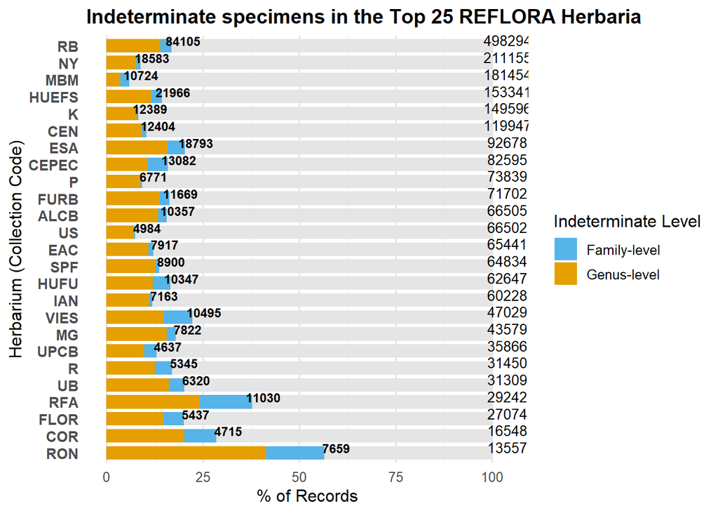

```r
##principal plot
p_stack <- ggplot(stacked_df, aes(x = collectionCode,
                                  y = percentage, fill = level)) +
  geom_col(data = stacked_df %>% group_by(collectionCode) %>% slice(1),
           aes(y = 100), fill = "grey90", width = 0.8) +
  geom_col(width = 0.8) +
  geom_text(data = plot_data, aes(x = collectionCode, y = 104, label = total),
            size = 3.5, vjust = 0, inherit.aes = FALSE) +
  scale_fill_manual(values = c("Genus-level" = "#E69F00",
                               "Family-level" = "#56B4E9")) +
  labs(
    x = "Herbarium (Collection Code)",
    y = "% of Records",
    fill = "Indeterminate Level",
    title = "Indeterminate specimens in the Top 25 REFLORA Herbaria"
  ) +
  coord_flip() +
  theme_minimal(base_size = 12) +
  theme(
    axis.text.y = element_text(size = 10, face = "bold"),
    panel.grid.major.y = element_blank(),
    panel.grid.major.x = element_line(color = "grey90"),
    plot.title = element_text(size = 14, face = "bold"),
    legend.position = "right"
  )

##adding text
p_stack <- p_stack +
  geom_text(data = plot_data,
            aes(x = collectionCode,
                y = perc_indet_total + 3,
                label = indet_total),
            size = 3.2, vjust = 0, fontface = "bold",
            inherit.aes = FALSE)

##showing
p_stack
```

## 2. Map of Brazil Showing the Distribution of Indeterminate Specimens

### 2.1 Clean and Convert Coordinates

To avoid long download times and possible knitting errors, the tutorial caches the cleaned, `sf`-converted result to a `.rds` file as well. The full cleaning step — coercing coordinates, dropping invalid values, and flagging suspect records with `CoordinateCleaner` — runs once:

```r
##factor
indets_br$taxonRank <- factor(indets_br$taxonRank,
                              levels = unique(indets_br$taxonRank),
                              ordered = TRUE)

##using scientific name for cleaning
indets_br <- indets_br %>%
  mutate(
    scientificName = ifelse(taxonRank == "GENUS", genus, family)
    # Use genus or family name as placeholder
  )

clean_invalid_coordinates <- function(df) {
  # Coerce columns to numeric
  df$decimalLatitude <- as.numeric(df$decimalLatitude)
  df$decimalLongitude <- as.numeric(df$decimalLongitude)

  # Remove rows with NA
  df <- df[!is.na(df$decimalLatitude) & !is.na(df$decimalLongitude), ]

  # Filter to valid latitude and longitude ranges
  df <- df[
    df$decimalLatitude >= -90 & df$decimalLatitude <= 90 &
      df$decimalLongitude >= -180 & df$decimalLongitude <= 180,
  ]

  return(df)
}

indets_br <- clean_invalid_coordinates(indets_br)

##defining the flags from Coordinate Cleaner
flags <- clean_coordinates(x = indets_br,
                           lon = "decimalLongitude",
                           lat = "decimalLatitude",
                           species = "genus",
                           tests = c("capitals", "centroids", "gbif",
                                     "institutions", "seas", "urban", "zeros"))

# Exclude problematic records
indets_br <- indets_br[flags$.summary,]

##transforming to sf
indets_br_sf <- indets_br %>%
  sf::st_as_sf(coords = c("decimalLongitude", "decimalLatitude"),
               crs = 4326)

saveRDS(indets_br_sf, "indets_br_sf.rds")
```

On a subsequent run:

```r
# Load indeterminate records, in sf format
indets_br_sf <- readRDS("indets_br_sf.rds")
```

### 2.2 Split Family- and Genus-Level Subsets

```r
#family
indets_br_sf_family <- indets_br_sf %>% filter(taxonRank == "FAMILY" & !is.na(family))
#genera
indets_br_sf_genus <- indets_br_sf %>% filter(taxonRank == "GENUS")
```

### 2.3 Load the Brazil Map and Join

```r
##Brazilian map
brazil <- geobr::read_country(year = 2020, simplified = TRUE)
brazil <- sf::st_transform(brazil, crs = 4326)

## Joining for eliminating outside frontiers
indets_br_sf_genus <- sf::st_join(indets_br_sf_genus,
                                  brazil, join = st_within, left = FALSE)
indets_br_sf_family  <- sf::st_join(indets_br_sf_family, brazil,
                                    join = st_within, left = FALSE)
```

### 2.4 Plotting

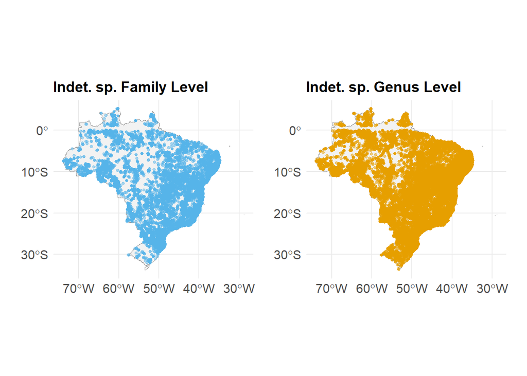

```r
## family plot
family_plot <- ggplot() +
  geom_sf(data = brazil, fill = "gray95", color = "gray60") +
  geom_sf(data = indets_br_sf_family, color = "#56B4E9", size = 1,
          alpha = 0.5) +
  labs(title = "Indet. sp. Family Level") +
  theme_minimal() +
  theme(
    plot.title = element_text(size = 14, face = "bold"),
    plot.subtitle = element_text(size = 12),
    axis.text.x = element_text(size = 12),
    axis.text.y = element_text(size = 12)
  )

## genus plot
genus_plot <- ggplot() +
  geom_sf(data = brazil, fill = "gray95", color = "gray60") +
  geom_sf(data = indets_br_sf_genus, color = "#E69F00", size = 1,
          alpha = 0.5) +
  labs(title = "Indet. sp. Genus Level") +
  theme_minimal() +
  theme(
    plot.title = element_text(size = 14, face = "bold"),
    plot.subtitle = element_text(size = 12),
    axis.text.x = element_text(size = 12),
    axis.text.y = element_text(size = 12)
  )

# Combine plots side by side
combined_plot <- family_plot + genus_plot +
  plot_layout(ncol = 2) &
  theme(plot.margin = margin(10, 10, 10, 10))

##displaying
combined_plot
```

## 3. Map of Brazil Displaying the Density of Indeterminate Specimens

This section reproduces **Figure 4** of the paper: a pair of smoothed kernel-density raster maps showing where indeterminate specimens concentrate across Brazil, independent of raw point overplotting.

### 3.1 Load the Brazil Shapefile and Subset the Data

```r
# Load Brazil shapefile
df_brazil <- ne_countries(scale = "medium", returnclass = "sf") %>%
  filter(admin == "Brazil")

# Create subsets of indet records at family and genus level
indets_br_family <- indets_br %>% filter(taxonRank == "FAMILY" & !is.na(family)
                                         &!is.na(decimalLatitude) &
                                         !is.na(decimalLongitude))
indets_br_genus <- indets_br %>% filter(taxonRank == "GENUS"
                                        &!is.na(decimalLatitude) &
                                         !is.na(decimalLongitude))
```

### 3.2 Family-Level Density Map

```r
# I. Convert to sf object
points_sf <- sf::st_as_sf(indets_br_family,
                          coords = c("decimalLongitude", "decimalLatitude"),
                          crs = 4326)

# II. Spatial filter using Brazil polygon
points_sf <- sf::st_join(points_sf, df_brazil, join = st_within, left = FALSE)

# III. Hexbin map to show sampling effort (collection gaps)
hex_data <- st_coordinates(points_sf) %>%
  as.data.frame() %>%
  rename(lon = X, lat = Y)

# IV. Smooth raster-style density map (masked to Brazil, yellow emphasized)
kde <- with(hex_data, kde2d(lon, lat, n = 300, lims = c(-74, -34, -34, 6), h = c(0.5, 0.5)))
density_df <- as.data.frame(expand.grid(x = kde$x, y = kde$y))
density_df$layer <- as.vector(kde$z)

# V. Convert to sf and mask to Brazil
st_geometry(density_df) <- st_sfc(lapply(1:nrow(density_df),
                          function(i) st_point(c(density_df$x[i],
                                                 density_df$y[i]))),
                                                            crs = 4326)
##density conversion
density_sf <- st_as_sf(density_df)
density_masked <- density_sf[df_brazil, ]
##masked coordinates
masked_coords <- st_coordinates(density_masked) %>%
                                          as.data.frame() %>%
                                       bind_cols(layer = density_masked$layer)

# VI. Family map
p_raster_family <- ggplot() +
  geom_sf(data = df_brazil, fill = viridis(1), colour = "gray40", size = 0.3) +
  geom_raster(data = masked_coords, aes(x = X, y = Y, fill = layer)) +
  geom_sf(data = df_brazil, fill = NA, colour = "gray40", size = 0.3) +
  coord_sf(xlim = c(-74, -34), ylim = c(-34, 6), expand = FALSE) +
  scale_fill_viridis_c("Specimen Density", option = "cividis",
                       trans = "sqrt",  direction = -1) +
  theme_void() +
  theme(legend.position = c(0.25, 0.25)) +
  labs(title = expression(bold("A) ") * "Indet. sp. (Family level)") )
```

### 3.3 Genus-Level Density Map

```r
#I. Convert to sf object
points_sf <- sf::st_as_sf(indets_br_genus,
                          coords = c("decimalLongitude", "decimalLatitude"),
                          crs = 4326)

#II. Spatial filter using Brazil polygon
points_sf <- sf::st_join(points_sf, df_brazil, join = st_within, left = FALSE)

#III. Hexbin map to show sampling effort (collection gaps)
hex_data <- st_coordinates(points_sf) %>%
                    as.data.frame() %>%
                    rename(lon = X, lat = Y)

#IV. Smooth raster-style density map (masked to Brazil, yellow emphasized)
kde <- with(hex_data, kde2d(lon, lat, n = 300, lims = c(-74, -34, -34, 6),
                            h = c(0.5, 0.5)))
density_df <- as.data.frame(expand.grid(x = kde$x, y = kde$y))
density_df$layer <- as.vector(kde$z)

#V. Convert to sf and mask to Brazil
st_geometry(density_df) <- st_sfc(lapply(1:nrow(density_df),
                                         function(i) st_point(c(density_df$x[i],
                                              density_df$y[i]))), crs = 4326)
density_sf <- st_as_sf(density_df)
density_masked <- density_sf[df_brazil, ]

masked_coords <- st_coordinates(density_masked) %>%
  as.data.frame() %>%
  bind_cols(layer = density_masked$layer)

#VI. Plot density map
p_raster_genus <- ggplot() +
        geom_sf(data = df_brazil,
                fill = viridis(1), colour = "gray40", size = 0.3) +
  geom_raster(data = masked_coords, aes(x = X, y = Y, fill = layer)) +
  geom_sf(data = df_brazil, fill = NA, colour = "gray40", size = 0.3) +
  coord_sf(xlim = c(-74, -34), ylim = c(-34, 6), expand = FALSE) +
  scale_fill_viridis_c("Specimen Density", option = "cividis", trans = "sqrt",  direction = -1) +
  theme_void() +
  theme(legend.position = c(0.25, 0.25)) +
  labs(title = expression(bold("B) ") * "Indet. sp. (Genus level)") )
```

### 3.4 Combine and Display

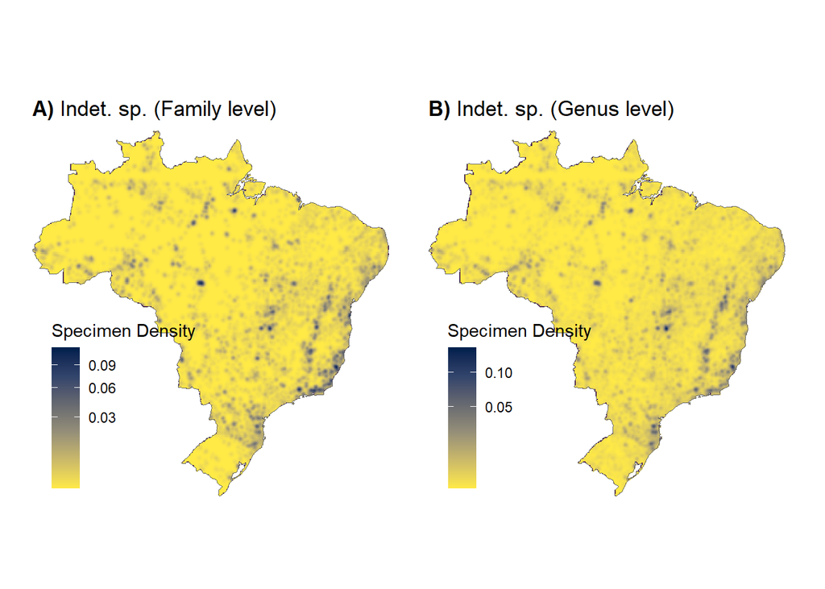

```r
combined_plot <- p_raster_family + p_raster_genus +
  plot_layout(ncol = 2) &
  theme(plot.margin = margin(10, 10, 10, 10))

##displaying
combined_plot
```

## Interpreting the Results

As discussed in the paper, herbaria with the largest collections (e.g., RB, NY, HUEFS) also hold the highest absolute counts of indeterminate specimens, but this does not scale proportionally with collection size. Some herbaria with smaller collections show relatively high *proportions* of unresolved records, which may make them better targets for taxonomic revision effort relative to their size. Across all herbaria, indeterminacy tends to concentrate more at the genus level than the family level. Because misidentified — rather than genuinely indeterminate — specimens can also inflate these counts, treat `reflora_indets()` output as a prioritization signal rather than a definitive gap analysis.

## See Also

- `reflora_records()`: Retrieve taxon-specific specimens
- `reflora_indets()`: Filter indeterminate specimens
- [refloraR software note (Calderón del Cid et al. 2026)](https://doi.org/10.1002/aps3.70081): the published paper this example is drawn from